# Used Cars with Neural Networks

Mladen Kolar (mkolar@chicagobooth.edu)

Load the H2O R package.

- R installation instructions are at http://h2o.ai/download

```r
library(h2o)
```

Start up a 1-node H2O server on your local machine, and allow it to use all CPU cores and up to 8GB of memory.

```r
h2o.init(nthreads=-1, max_mem_size="8G")
```

```
##
## H2O is not running yet, starting it now...
##
## Note:  In case of errors look at the following log files:
##     /tmp/RtmprhT8L6/file6f753124f70/h2o_mkolar_started_from_r.out
##     /tmp/RtmprhT8L6/file6f7561f8fb87/h2o_mkolar_started_from_r.err
##
##
## Starting H2O JVM and connecting: .. Connection successful!
##
## R is connected to the H2O cluster:
##     H2O cluster uptime:         1 seconds 74 milliseconds
##     H2O cluster timezone:       America/Chicago
##     H2O data parsing timezone:  UTC
##     H2O cluster version:        3.40.0.1
##     H2O cluster version age:    8 days
##     H2O cluster name:           H2O_started_from_R_mkolar_siq969
##     H2O cluster total nodes:    1
##     H2O cluster total memory:   8.00 GB
##     H2O cluster total cores:    12
##     H2O cluster allowed cores:  12
##     H2O cluster healthy:        TRUE
##     H2O Connection ip:          localhost
##     H2O Connection port:        54321
##     H2O Connection proxy:       NA
##     H2O Internal Security:      FALSE
##     R Version:                  R version 4.2.2 Patched (2022-11-10 r83330)
```

```r
h2o.no_progress()
```

The `h2o.deeplearning` function fits H2O’s Deep Learning models from within R.

```r
help(h2o.deeplearning)
```

While H2O Deep Learning has many parameters, it is quite easy to use. Most often we can use the default parameters for many of the inputs. We should change the following parameters:

- the number and sizes of hidden layers;
- the number of epochs and the activation function;
- add some regularization technique.

We will apply it to `UsedCars` data, which we used earlier with boosting.

```r
# download the file if it does not exist
if (!file.exists("UsedCars.csv"))
  download.file('https://github.com/ChicagoBoothML/MLClassData/raw/master/UsedCars/UsedCars.csv',
                'UsedCars.csv')

df <- h2o.importFile('UsedCars.csv')
dim( df )
```

```
## [1] 20063    11
```

```r
df
```

```
##   price trim isOneOwner mileage year  color displacement     fuel region
## 1  2988  320          f  193296 1995  Black          3.2 Gasoline    SoA
## 2  6595  320          f  129948 1995  other          3.2 Gasoline    Mid
## 3  7993  320          f  140428 1997  White          3.2 Gasoline    Mid
## 4  5995  420          f  113622 1999 Silver          4.2 Gasoline    Mid
## 5  3000  420          f  167673 1999 Silver          4.2 Gasoline    SoA
## 6  7400  430          f   82419 2002  White          4.3 Gasoline    Mid
##   soundSystem wheelType
## 1        unsp     Alloy
## 2     Premium     Alloy
## 3        Bose     Alloy
## 4        unsp     Alloy
## 5        unsp     Alloy
## 6        Bose     Alloy
##
## [20063 rows x 11 columns]
```

The data contains 20,063 rows and 11 columns (5 numerical and 6 categorical). The target is the `price` column.

We split the data 3 ways:

- 60% for training,
- 20% for validation (hyper parameter tuning), and
- 20% for final testing.

```r
splits <- h2o.splitFrame(df, c(0.6,0.2), seed=1)
train  <- h2o.assign(splits[[1]], "train.hex") # 60%
valid  <- h2o.assign(splits[[2]], "valid.hex") # 20%
test   <- h2o.assign(splits[[3]], "test.hex")  # 20%
```

We build our first Deep Learning model where we predict the `price` column using the remaining 4 numerical and 6 categorical variables. `h2o` will automatically use automatic one-hot encoding.

```r
response <- "price"
predictors <- setdiff(names(df), response)
predictors
```

```
##  [1] "trim"         "isOneOwner"   "mileage"      "year"         "color"
##  [6] "displacement" "fuel"         "region"       "soundSystem"  "wheelType"
```

```r
m1 <- h2o.deeplearning(
  model_id="dl_model_first",
  training_frame=train,
  validation_frame=valid,   ## validation data are used for scoring and early stopping
  x=predictors,
  y=response,
  activation="Rectifier",   ## default
  hidden=c(100,100),
  epochs=100,
  variable_importances=T    ## not enabled by default
)
summary(m1)
```

```
## Model Details:
## ==============
##
## H2ORegressionModel: deeplearning
## Model Key:  dl_model_first
## Status of Neuron Layers: predicting price, regression, gaussian distribution, Quadratic loss, 14,301 weights/biases, 176.3 KB, 1,300,390 training samples, mini-batch size 1
##   layer units      type dropout       l1       l2 mean_rate rate_rms momentum
## 1     1    40     Input  0.00 %       NA       NA        NA       NA       NA
## 2     2   100 Rectifier  0.00 % 0.000000 0.000000  0.162383 0.370081 0.000000
## 3     3   100 Rectifier  0.00 % 0.000000 0.000000  0.221478 0.215564 0.000000
## 4     4     1    Linear      NA 0.000000 0.000000  0.003122 0.002040 0.000000
##   mean_weight weight_rms mean_bias bias_rms
## 1          NA         NA        NA       NA
## 2   -0.007643   0.123714  0.324223 0.122689
## 3   -0.037423   0.115403  0.872612 0.093027
## 4    0.025673   0.088862 -0.024160 0.000000
##
## H2ORegressionMetrics: deeplearning
## ** Reported on training data. **
## ** Metrics reported on temporary training frame with 9980 samples **
##
## MSE:  18792258
## RMSE:  4335
## MAE:  3062
## RMSLE:  0.185
## Mean Residual Deviance :  18792258
##
##
## H2ORegressionMetrics: deeplearning
## ** Reported on validation data. **
## ** Metrics reported on full validation frame **
##
## MSE:  20490808
## RMSE:  4527
## MAE:  3167
## RMSLE:  0.19
## Mean Residual Deviance :  20490808
##
##
##
```

[output cut: 25 more lines]

```
##        variable relative_importance scaled_importance percentage
## 1          trim            1.000000          1.000000   0.044415
## 2          year            0.981915          0.981915   0.043612
## 3  displacement            0.876612          0.876612   0.038935
## 4 fuel.Gasoline            0.799011          0.799011   0.035488
## 5       mileage            0.741681          0.741681   0.032942
##
## ---
##                   variable relative_importance scaled_importance percentage
## 35      region.missing(NA)            0.000000          0.000000   0.000000
## 36       color.missing(NA)            0.000000          0.000000   0.000000
## 37 soundSystem.missing(NA)            0.000000          0.000000   0.000000
## 38   wheelType.missing(NA)            0.000000          0.000000   0.000000
## 39        fuel.missing(NA)            0.000000          0.000000   0.000000
## 40  isOneOwner.missing(NA)            0.000000          0.000000   0.000000
```

h2o implements the method of Gedeon

- http://users.cecs.anu.edu.au/~Tom.Gedeon/pdfs/ContribDataMinv2.pdf

to compute the relative variable importance in descending order of importance.

```r
head(as.data.frame(h2o.varimp(m1)), 10)
```

```
##           variable relative_importance scaled_importance percentage
## 1             trim               1.000             1.000     0.0444
## 2             year               0.982             0.982     0.0436
## 3     displacement               0.877             0.877     0.0389
## 4    fuel.Gasoline               0.799             0.799     0.0355
## 5          mileage               0.742             0.742     0.0329
## 6      fuel.Hybrid               0.700             0.700     0.0311
## 7      fuel.Diesel               0.682             0.682     0.0303
## 8   wheelType.unsp               0.679             0.679     0.0302
## 9      color.White               0.676             0.676     0.0300
## 10 wheelType.Alloy               0.672             0.672     0.0299
```

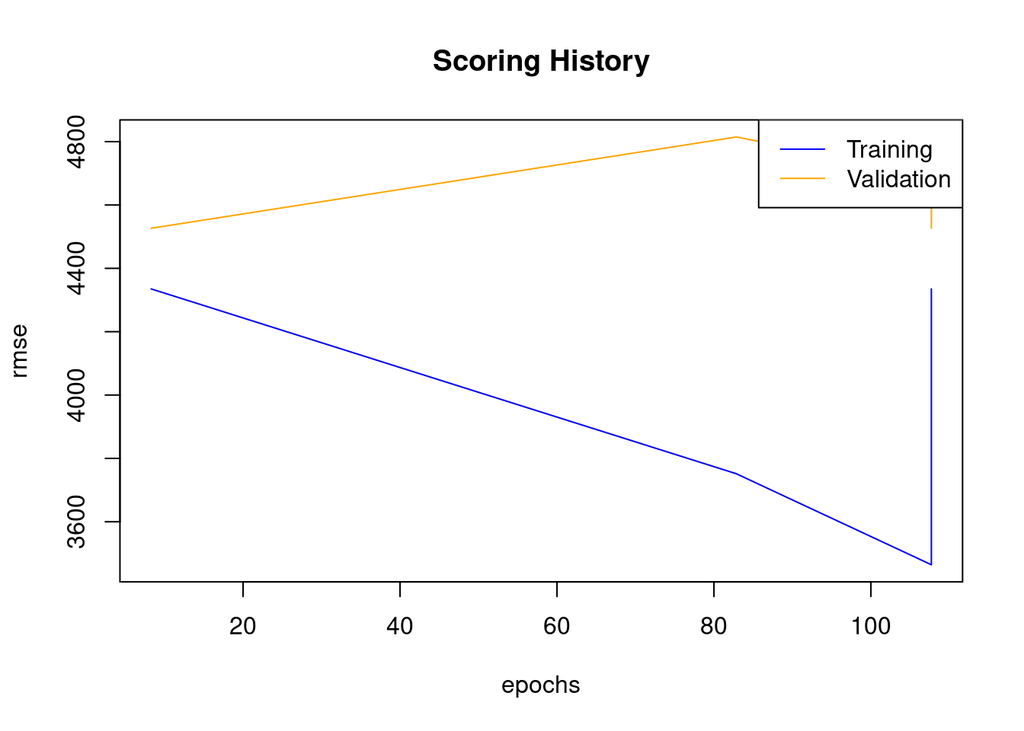

```r
plot(m1)
```

**Early Stopping**

Here we stop training when the MSE converges

- the moving average of length 2 does not improve by at least 1% for 2 consecutive scoring events.

```r
m2 <- h2o.deeplearning(
  model_id="dl_model_faster",
  training_frame=train,
  validation_frame=valid,
  x=predictors,
  y=response,
  hidden=c(16,16,16,16),               ## small network, runs faster
  epochs=1000000,                      ## hopefully converges earlier...
  stopping_rounds=2,
  stopping_metric="MSE",               ## could be "MSE","logloss","r2"
  stopping_tolerance=0.01
)
summary(m2)
```

```
## Model Details:
## ==============
##
## H2ORegressionModel: deeplearning
## Model Key:  dl_model_faster
## Status of Neuron Layers: predicting price, regression, gaussian distribution, Quadratic loss, 1,489 weights/biases, 25.8 KB, 7,700,231 training samples, mini-batch size 1
##   layer units      type dropout       l1       l2 mean_rate rate_rms momentum
## 1     1    40     Input  0.00 %       NA       NA        NA       NA       NA
## 2     2    16 Rectifier  0.00 % 0.000000 0.000000  0.153325 0.370529 0.000000
## 3     3    16 Rectifier  0.00 % 0.000000 0.000000  0.004263 0.002727 0.000000
## 4     4    16 Rectifier  0.00 % 0.000000 0.000000  0.006267 0.005484 0.000000
## 5     5    16 Rectifier  0.00 % 0.000000 0.000000  0.021965 0.045354 0.000000
## 6     6     1    Linear      NA 0.000000 0.000000  0.001867 0.001792 0.000000
##   mean_weight weight_rms mean_bias bias_rms
## 1          NA         NA        NA       NA
## 2    0.017104   0.238495  0.516658 0.182987
## 3   -0.049442   0.380247  0.975469 0.136757
## 4   -0.073797   0.358019  0.902505 0.188566
## 5   -0.097069   0.422242  0.790148 0.422249
## 6   -0.034668   0.331338  0.168129 0.000000
##
## H2ORegressionMetrics: deeplearning
## ** Reported on training data. **
## ** Metrics reported on temporary training frame with 10021 samples **
##
## MSE:  15290906
## RMSE:  3910
## MAE:  2741
## RMSLE:  NaN
## Mean Residual Deviance :  15290906
##
##
## H2ORegressionMetrics: deeplearning
## ** Reported on validation data. **
## ** Metrics reported on full validation frame **
##
## MSE:  18352113
## RMSE:  4284
## MAE:  2946
## RMSLE:  0.186
```

[output cut: 35 more lines]

```
##       variable relative_importance scaled_importance percentage
## 1         trim            1.000000          1.000000   0.079554
## 2         year            0.823464          0.823464   0.065510
## 3 displacement            0.694144          0.694144   0.055222
## 4      mileage            0.561659          0.561659   0.044682
## 5  fuel.Diesel            0.518330          0.518330   0.041235
##
## ---
##                   variable relative_importance scaled_importance percentage
## 35      region.missing(NA)            0.000000          0.000000   0.000000
## 36       color.missing(NA)            0.000000          0.000000   0.000000
## 37 soundSystem.missing(NA)            0.000000          0.000000   0.000000
## 38   wheelType.missing(NA)            0.000000          0.000000   0.000000
## 39        fuel.missing(NA)            0.000000          0.000000   0.000000
## 40  isOneOwner.missing(NA)            0.000000          0.000000   0.000000
```

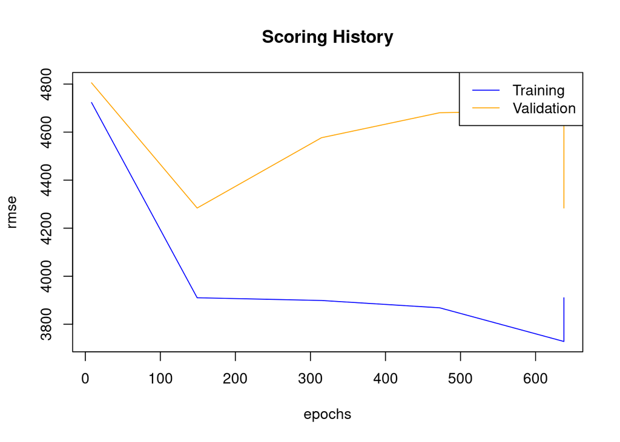

```r
plot(m2)
```

**Tuning**

You can find more information on different tuning parameters in the H2O Deep Learning booklet

- https://www.h2o.ai/resources/booklet/deep-learning-with-h2o/

Here we are going to try and use penalty parameters.

```r
m3 <- h2o.deeplearning(
  model_id="dl_model_tuned",
  training_frame=train,
  validation_frame=valid,
  x=predictors,
  y=response,
  hidden=c(32,32,32,32),      ## more hidden layers -> more complex interactions
  epochs=1000,                ## to keep it short enough
  score_duty_cycle=0.025,     ## don't score more than 2.5% of the wall time
  l1=1e-5,                    ## add some L1/L2 regularization
  l2=1e-5,
  max_w2=10,                  ## helps stability for Rectifier
  stopping_rounds=2,
  stopping_metric="MSE",      ## could be "MSE","logloss","r2"
  stopping_tolerance=0.01
)
summary(m3)
```

```
## Model Details:
## ==============
##
## H2ORegressionModel: deeplearning
## Model Key:  dl_model_tuned
## Status of Neuron Layers: predicting price, regression, gaussian distribution, Quadratic loss, 4,513 weights/biases, 62.0 KB, 3,799,279 training samples, mini-batch size 1
##   layer units      type dropout       l1       l2 mean_rate rate_rms momentum
## 1     1    40     Input  0.00 %       NA       NA        NA       NA       NA
## 2     2    32 Rectifier  0.00 % 0.000010 0.000010  0.156847 0.371031 0.000000
## 3     3    32 Rectifier  0.00 % 0.000010 0.000010  0.012575 0.007493 0.000000
## 4     4    32 Rectifier  0.00 % 0.000010 0.000010  0.012360 0.010116 0.000000
## 5     5    32 Rectifier  0.00 % 0.000010 0.000010  0.081260 0.120360 0.000000
## 6     6     1    Linear      NA 0.000010 0.000010  0.003405 0.002375 0.000000
##   mean_weight weight_rms mean_bias bias_rms
## 1          NA         NA        NA       NA
## 2    0.002000   0.200694  0.388771 0.147333
## 3   -0.034617   0.220124  0.819866 0.132108
## 4   -0.059161   0.216954  0.869071 0.123530
## 5   -0.061034   0.221488  0.867849 0.145475
## 6    0.087037   0.205140 -0.075957 0.000000
##
## H2ORegressionMetrics: deeplearning
## ** Reported on training data. **
## ** Metrics reported on temporary training frame with 10001 samples **
##
## MSE:  16107677
## RMSE:  4013
## MAE:  2808
## RMSLE:  NaN
## Mean Residual Deviance :  16107677
##
##
## H2ORegressionMetrics: deeplearning
## ** Reported on validation data. **
## ** Metrics reported on full validation frame **
##
## MSE:  20306396
## RMSE:  4506
## MAE:  3106
## RMSLE:  NaN
```

[output cut: 35 more lines]

```
##       variable relative_importance scaled_importance percentage
## 1         year            1.000000          1.000000   0.052020
## 2      mileage            0.922387          0.922387   0.047983
## 3         trim            0.901862          0.901862   0.046915
## 4 displacement            0.840128          0.840128   0.043703
## 5  fuel.Hybrid            0.628333          0.628333   0.032686
##
## ---
##                   variable relative_importance scaled_importance percentage
## 35      region.missing(NA)            0.000000          0.000000   0.000000
## 36       color.missing(NA)            0.000000          0.000000   0.000000
## 37 soundSystem.missing(NA)            0.000000          0.000000   0.000000
## 38   wheelType.missing(NA)            0.000000          0.000000   0.000000
## 39        fuel.missing(NA)            0.000000          0.000000   0.000000
## 40  isOneOwner.missing(NA)            0.000000          0.000000   0.000000
```

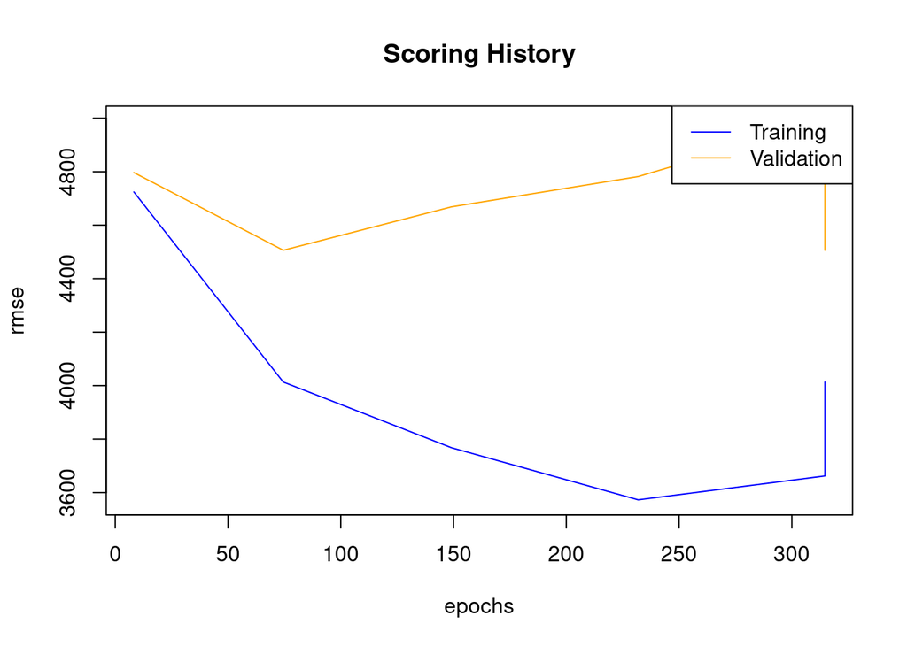

```r
plot(m3)
```

```r
h2o.performance(m1, newdata=test)
```

```
## H2ORegressionMetrics: deeplearning
##
## MSE:  20123323
## RMSE:  4486
## MAE:  3181
## RMSLE:  0.198
## Mean Residual Deviance :  20123323
```

```r
h2o.performance(m2, newdata=test)
```

```
## H2ORegressionMetrics: deeplearning
##
## MSE:  17545737
## RMSE:  4189
## MAE:  2937
## RMSLE:  0.188
## Mean Residual Deviance :  17545737
```

```r
h2o.performance(m3, newdata=test)
```

```
## H2ORegressionMetrics: deeplearning
##
## MSE:  19789806
## RMSE:  4449
## MAE:  3085
## RMSLE:  0.194
## Mean Residual Deviance :  19789806
```

**Tuning with Grid Search**

A lot of parameters can impact model accuracy

- hyper-parameter tuning is especially important for Deep Learning.

The simplest way is to perform a brute-force scan over all combinations of specified parameters.

```r
hyper_params <- list(
  hidden=list(c(32,32,32),c(64,64)),
  input_dropout_ratio=c(0,0.05),
  l1=c(0,1e-5,1e-3),
  l2=c(0,1e-5,1e-3),
  max_w2=c(5,10)
)

grid <- h2o.grid(
  algorithm="deeplearning",
  grid_id="dl_grid",
  training_frame=train,
  validation_frame=valid,
  x=predictors,
  y=response,
  epochs=10,
  stopping_metric="MSE",
  stopping_tolerance=1e-2,        ## stop when MSE does not improve by >=1% for 2 scoring events
  stopping_rounds=2,
  score_duty_cycle=0.025,         ## don't score more than 2.5% of the wall time
  hyper_params=hyper_params
)
```

```r
grid
```

```
## H2O Grid Details
## ================
##
## Grid ID: dl_grid
## Used hyper parameters:
##   -  hidden
##   -  input_dropout_ratio
##   -  l1
##   -  l2
##   -  max_w2
## Number of models: 72
## Number of failed models: 0
##
## Hyper-Parameter Search Summary: ordered by increasing residual_deviance
##         hidden input_dropout_ratio      l1      l2   max_w2        model_ids
## 1 [32, 32, 32]             0.00000 0.00000 0.00001  5.00000 dl_grid_model_13
## 2     [64, 64]             0.00000 0.00000 0.00000  5.00000  dl_grid_model_2
## 3     [64, 64]             0.00000 0.00001 0.00000  5.00000  dl_grid_model_6
## 4     [64, 64]             0.00000 0.00001 0.00100  5.00000 dl_grid_model_30
## 5     [64, 64]             0.00000 0.00001 0.00000 10.00000 dl_grid_model_42
##   residual_deviance
## 1    18817516.65732
## 2    19550517.69721
## 3    19652521.85546
## 4    19658719.21709
## 5    19795150.07401
##
## ---
##          hidden input_dropout_ratio      l1      l2   max_w2        model_ids
## 67 [32, 32, 32]             0.05000 0.00001 0.00100 10.00000 dl_grid_model_67
## 68     [64, 64]             0.05000 0.00100 0.00000 10.00000 dl_grid_model_48
## 69 [32, 32, 32]             0.05000 0.00100 0.00000  5.00000 dl_grid_model_11
## 70     [64, 64]             0.00000 0.00001 0.00100 10.00000 dl_grid_model_66
## 71     [64, 64]             0.00000 0.00100 0.00000 10.00000 dl_grid_model_46
## 72     [64, 64]             0.05000 0.00100 0.00000  5.00000 dl_grid_model_12
##    residual_deviance
## 67    24567243.51094
## 68    25100162.59918
## 69    25195643.31586
## 70    25756742.08195
## 71    25822116.62415
## 72    26653187.32262
```

```r
grid <- h2o.getGrid("dl_grid",sort_by="rmse",decreasing=FALSE)
grid
```

```
## H2O Grid Details
## ================
##
## Grid ID: dl_grid
## Used hyper parameters:
##   -  hidden
##   -  input_dropout_ratio
##   -  l1
##   -  l2
##   -  max_w2
## Number of models: 72
## Number of failed models: 0
##
## Hyper-Parameter Search Summary: ordered by increasing rmse
##         hidden input_dropout_ratio      l1      l2   max_w2        model_ids
## 1 [32, 32, 32]             0.00000 0.00000 0.00001  5.00000 dl_grid_model_13
## 2     [64, 64]             0.00000 0.00000 0.00000  5.00000  dl_grid_model_2
## 3     [64, 64]             0.00000 0.00001 0.00000  5.00000  dl_grid_model_6
## 4     [64, 64]             0.00000 0.00001 0.00100  5.00000 dl_grid_model_30
## 5     [64, 64]             0.00000 0.00001 0.00000 10.00000 dl_grid_model_42
##         rmse
## 1 4337.91617
## 2 4421.59674
## 3 4433.11649
## 4 4433.81542
## 5 4449.17409
##
## ---
##          hidden input_dropout_ratio      l1      l2   max_w2        model_ids
## 67 [32, 32, 32]             0.05000 0.00001 0.00100 10.00000 dl_grid_model_67
## 68     [64, 64]             0.05000 0.00100 0.00000 10.00000 dl_grid_model_48
## 69 [32, 32, 32]             0.05000 0.00100 0.00000  5.00000 dl_grid_model_11
## 70     [64, 64]             0.00000 0.00001 0.00100 10.00000 dl_grid_model_66
## 71     [64, 64]             0.00000 0.00100 0.00000 10.00000 dl_grid_model_46
## 72     [64, 64]             0.05000 0.00100 0.00000  5.00000 dl_grid_model_12
##          rmse
## 67 4956.53543
## 68 5010.00625
## 69 5019.52620
## 70 5075.11006
## 71 5081.54668
## 72 5162.67250
```

Find the best model and its full set of parameters

```r
grid@summary_table[1,]
```

```
## Hyper-Parameter Search Summary: ordered by increasing rmse
##         hidden input_dropout_ratio      l1      l2  max_w2        model_ids
## 1 [32, 32, 32]             0.00000 0.00000 0.00001 5.00000 dl_grid_model_13
##         rmse
## 1 4337.91617
```

```r
best_model <- h2o.getModel(grid@model_ids[[1]])
best_model
```

```
## Model Details:
## ==============
##
## H2ORegressionModel: deeplearning
## Model ID:  dl_grid_model_13
## Status of Neuron Layers: predicting price, regression, gaussian distribution, Quadratic loss, 3,457 weights/biases, 48.7 KB, 120,740 training samples, mini-batch size 1
##   layer units      type dropout       l1       l2 mean_rate rate_rms momentum
## 1     1    40     Input  0.00 %       NA       NA        NA       NA       NA
## 2     2    32 Rectifier  0.00 % 0.000000 0.000010  0.156350 0.370407 0.000000
## 3     3    32 Rectifier  0.00 % 0.000000 0.000010  0.012606 0.010415 0.000000
## 4     4    32 Rectifier  0.00 % 0.000000 0.000010  0.099354 0.141652 0.000000
## 5     5     1    Linear      NA 0.000000 0.000010  0.002387 0.002203 0.000000
##   mean_weight weight_rms mean_bias bias_rms
## 1          NA         NA        NA       NA
## 2   -0.009005   0.176857  0.454662 0.119629
## 3   -0.040416   0.193798  0.915642 0.055761
## 4   -0.047196   0.197332  0.882731 0.123215
## 5    0.027243   0.142094  0.014890 0.000000
##
##
## H2ORegressionMetrics: deeplearning
## ** Reported on training data. **
## ** Metrics reported on temporary training frame with 10025 samples **
##
## MSE:  17631597
## RMSE:  4199
## MAE:  2914
## RMSLE:  0.182
## Mean Residual Deviance :  17631597
##
##
## H2ORegressionMetrics: deeplearning
## ** Reported on validation data. **
## ** Metrics reported on full validation frame **
##
## MSE:  18817517
## RMSE:  4338
## MAE:  3022
## RMSLE:  0.182
## Mean Residual Deviance :  18817517
```

```r
h2o.performance(best_model, newdata=test)
```

```
## H2ORegressionMetrics: deeplearning
##
## MSE:  18875957
## RMSE:  4345
## MAE:  3032
## RMSLE:  0.191
## Mean Residual Deviance :  18875957
```

**Tuning with Random Search**

Hyper-parameter search for more than 4 parameters can be done more efficiently with random parameter search.

```r
hyper_params <- list(
  activation=c("Rectifier","Tanh","RectifierWithDropout","TanhWithDropout"),
  hidden=list(c(20,20),c(50,50),c(30,30,30),c(25,25,25,25),c(64,64,64,64)),
  input_dropout_ratio=c(0,0.05),
  l1=seq(0,1e-4,1e-6),
  l2=seq(0,1e-4,1e-6),
  max_w2=c(5,10,15)
)

## Stop once the top 5 models are within 1% of each other
##
##     - the windowed average varies less than 1%
##
search_criteria = list(
  strategy = "RandomDiscrete",
  max_runtime_secs = 360,
  max_models = 100,
  seed=1,
  stopping_rounds=5,
  stopping_tolerance=1e-2
  )

dl_random_grid <- h2o.grid(
  algorithm="deeplearning",
  grid_id = "dl_grid_random",
  training_frame=train,
  validation_frame=valid,
  x=predictors,
  y=response,
  epochs=10,
  stopping_metric="MSE",
  stopping_tolerance=1e-2,        ## stop when MSE does not improve by >=1% for 2 scoring events
  stopping_rounds=2,
  score_duty_cycle=0.025,         ## don't score more than 2.5% of the wall time
  hyper_params = hyper_params,
  search_criteria = search_criteria
)
```

```r
grid <- h2o.getGrid("dl_grid_random", sort_by="RMSE", decreasing=FALSE)
grid
```

```
## H2O Grid Details
## ================
##
## Grid ID: dl_grid_random
## Used hyper parameters:
##   -  activation
##   -  hidden
##   -  input_dropout_ratio
##   -  l1
##   -  l2
##   -  max_w2
## Number of models: 100
## Number of failed models: 0
##
## Hyper-Parameter Search Summary: ordered by increasing RMSE
##   activation           hidden input_dropout_ratio      l1      l2   max_w2
## 1  Rectifier         [50, 50]             0.00000 0.00000 0.00004 15.00000
## 2       Tanh     [30, 30, 30]             0.00000 0.00005 0.00008  5.00000
## 3  Rectifier [25, 25, 25, 25]             0.00000 0.00004 0.00003 15.00000
## 4       Tanh [25, 25, 25, 25]             0.00000 0.00001 0.00004 10.00000
## 5  Rectifier [25, 25, 25, 25]             0.00000 0.00005 0.00001 15.00000
##                 model_ids       rmse
## 1 dl_grid_random_model_54 4390.54114
## 2 dl_grid_random_model_46 4424.75677
## 3 dl_grid_random_model_74 4431.95689
## 4 dl_grid_random_model_55 4436.44638
## 5 dl_grid_random_model_58 4442.21182
##
## ---
##               activation           hidden input_dropout_ratio      l1      l2
## 95       TanhWithDropout [25, 25, 25, 25]             0.00000 0.00003 0.00004
## 96  RectifierWithDropout         [20, 20]             0.05000 0.00009 0.00009
## 97       TanhWithDropout [25, 25, 25, 25]             0.05000 0.00003 0.00003
## 98       TanhWithDropout [25, 25, 25, 25]             0.00000 0.00005 0.00002
## 99  RectifierWithDropout [25, 25, 25, 25]             0.05000 0.00003 0.00002
## 100      TanhWithDropout [25, 25, 25, 25]             0.00000 0.00001 0.00000
##       max_w2               model_ids       rmse
## 95  10.00000 dl_grid_random_model_43 8484.64174
## 96  15.00000 dl_grid_random_model_10 8872.05061
## 97   5.00000  dl_grid_random_model_3 8891.51975
## 98  15.00000 dl_grid_random_model_92 8995.40721
## 99   5.00000 dl_grid_random_model_66 9207.66398
## 100 10.00000 dl_grid_random_model_13 9340.40605
```

```r
grid@summary_table[1,]
```

```
## Hyper-Parameter Search Summary: ordered by increasing RMSE
##   activation   hidden input_dropout_ratio      l1      l2   max_w2
## 1  Rectifier [50, 50]             0.00000 0.00000 0.00004 15.00000
##                 model_ids       rmse
## 1 dl_grid_random_model_54 4390.54114
```

```r
best_model <- h2o.getModel(grid@model_ids[[1]]) ## model with lowest RMSE
best_model
```

```
## Model Details:
## ==============
##
## H2ORegressionModel: deeplearning
## Model ID:  dl_grid_random_model_54
## Status of Neuron Layers: predicting price, regression, gaussian distribution, Quadratic loss, 4,651 weights/biases, 62.1 KB, 120,740 training samples, mini-batch size 1
##   layer units      type dropout       l1       l2 mean_rate rate_rms momentum
## 1     1    40     Input  0.00 %       NA       NA        NA       NA       NA
## 2     2    50 Rectifier  0.00 % 0.000001 0.000042  0.159568 0.371150 0.000000
## 3     3    50 Rectifier  0.00 % 0.000001 0.000042  0.111567 0.146417 0.000000
## 4     4     1    Linear      NA 0.000001 0.000042  0.002433 0.001833 0.000000
##   mean_weight weight_rms mean_bias bias_rms
## 1          NA         NA        NA       NA
## 2   -0.010388   0.151124  0.345122 0.132945
## 3   -0.045592   0.161853  0.772309 0.206796
## 4    0.024195   0.123443  0.005263 0.000000
##
##
## H2ORegressionMetrics: deeplearning
## ** Reported on training data. **
## ** Metrics reported on temporary training frame with 10048 samples **
##
## MSE:  18108695
## RMSE:  4255
## MAE:  2965
## RMSLE:  0.187
## Mean Residual Deviance :  18108695
##
##
## H2ORegressionMetrics: deeplearning
## ** Reported on validation data. **
## ** Metrics reported on full validation frame **
##
## MSE:  19276851
## RMSE:  4391
## MAE:  3065
## RMSLE:  0.191
## Mean Residual Deviance :  19276851
```

```r
h2o.performance(best_model, newdata=test)
```

```
## H2ORegressionMetrics: deeplearning
##
## MSE:  19228883
## RMSE:  4385
## MAE:  3077
## RMSLE:  0.2
## Mean Residual Deviance :  19228883
```